# Statistical analysis of the metagenomic data_Wildebeest

### Required packages

```r
#Packages used
#library(dada2); packageVersion("dada2")
library(DECIPHER)
library(phyloseq)
library(Biostrings)
library(ggplot2)
library(vegan)
library(car)
library(DescTools)
library(ggtext)
library(tibble)
library(microbiomeMarker)
#library(microbiomeMarker)
```

Reading the phyloseq object created in the DADA2 pipeline.

```r
PS1 <- readRDS("PS1.rds")
```

# Rarefaction curves

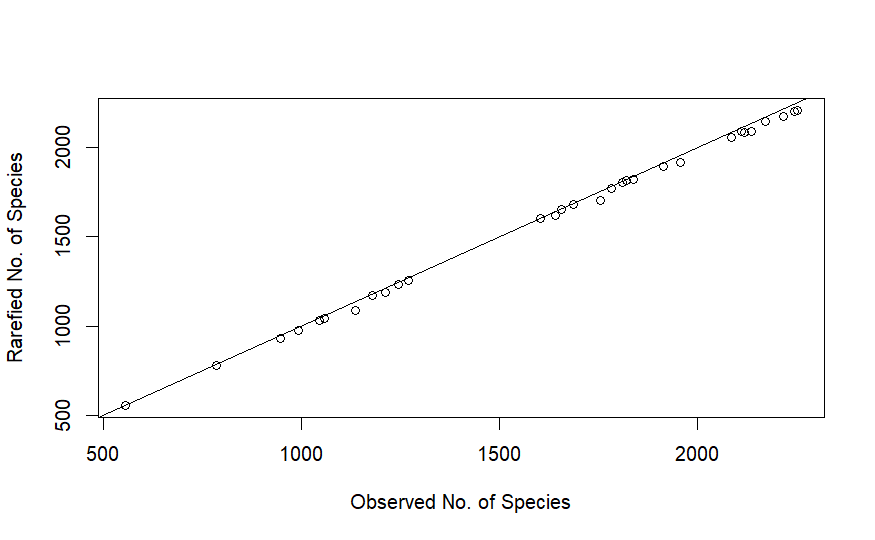

```r
S <- specnumber(otu_table(PS1)) # observed number of species
raremax <- min(rowSums(otu_table(PS1)))
otu_data <-  otu_table(PS1)
OTU_df <- as.data.frame(otu_data)
OTU_matrix <- as.matrix(OTU_df)
Srare <- rarefy(OTU_matrix, raremax)
plot(S, Srare, xlab = "Observed No. of Species", ylab = "Rarefied No. of Species")
abline(0, 1)
```

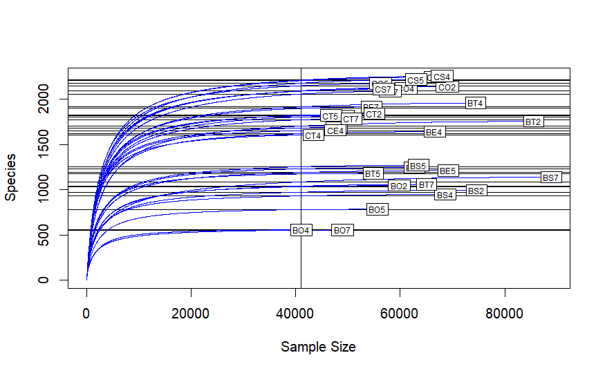

```r
rarecurve(OTU_df, step = 50, sample = raremax,  col = "blue",
          cex = 0.6, tidy = F)
```

# Rarefaction

To obtain repeatable random sub-sampling, set seed to 19751226)

```r
PS_normal <- rarefy_even_depth(PS1, rngseed=19751226, sample.size=min(sample_sums(PS1)), replace=F)
```

## Relative abundance Bar plot

The 30 most dependent taxa were selected.

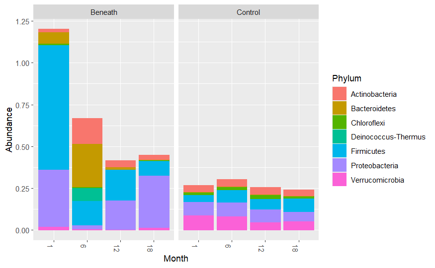

```r
top30 <- names(sort(taxa_sums(PS_normal), decreasing=TRUE))[1:30]
ps.top30 <- transform_sample_counts(PS_normal, function(OTU) OTU/sum(OTU))
ps.top30 <- prune_taxa(top30, ps.top30)
plot_bar(ps.top30, x="Month", fill="Phylum")+
  facet_wrap(~Group)+#"Kingdom", "Phylum", "Class", "Order", "Family", "Genus", "Species"
  geom_bar(aes(color=Phylum, fill=Phylum), stat="identity", position="stack")
```

# Diversity

## Alpha diversity

Visualize alpha-diversity by the Observed richness and Simpson,s diversity

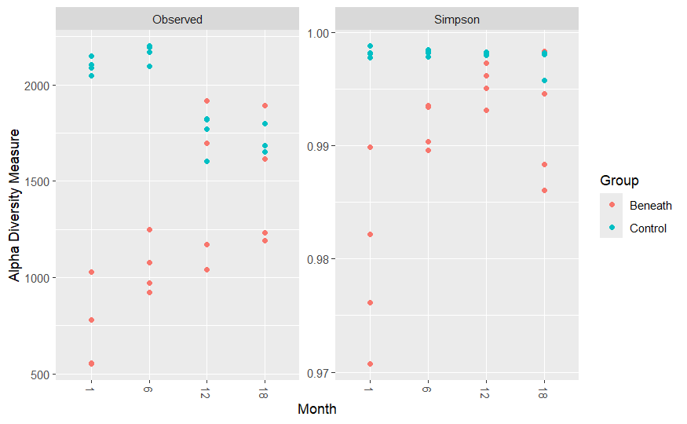

```r
plot_richness(PS_normal, x="Month", measures=c("Observed","Simpson"),
              color="Group")
```

```r
library(tidyr)

rich =
  estimate_richness(PS_normal, measures = c(
    "Observed", "Chao1", "ACE", "Shannon", "Simpson", "InvSimpson", "Fisher"))
rich_res <-
  cbind(PS_normal@sam_data,rich$Observed,rich$Chao1,rich$ACE,
        rich$Shannon,rich$Simpson,rich$InvSimpson,rich$Fisher)
rich_res =
  rich_res%>%
  unite(Treament_Month,Group, Month, sep = "_", remove = F)
colnames(rich_res) <- c("Subject","Treament_Month","Group","Month","Site",
                        "Observed", "Chao1", "ACE", "Shannon", "Simpson", "InvSimpson", "Fisher")
```

Testing the assumption of normality

```r
#Observed richness
Bnth_1_Obs_norm <- shapiro.test(rich_res[c(5:8),c(6)])
Bnth_6_Obs_norm <- shapiro.test(rich_res[c(9:12),c(6)])
Bnth_12_Obs_norm <- shapiro.test(rich_res[c(13:16),c(6)])
Bnth_18_Obs_norm <- shapiro.test(rich_res[c(1:4),c(6)])
Ctrl_1_Obs_norm <- shapiro.test(rich_res[c(20:23),c(6)])
Ctrl_6_Obs_norm <- shapiro.test(rich_res[c(24:27),c(6)])
Ctrl_12_Obs_norm <- shapiro.test(rich_res[c(28:31),c(6)])
Ctrl_18_Obs_norm <- shapiro.test(rich_res[c(17:19),c(6)])
as.numeric(list(Bnth_1_Obs_norm$p.value[1],Bnth_6_Obs_norm$p.value[1],
                              Bnth_12_Obs_norm$p.value[1],Bnth_18_Obs_norm$p.value[1],
                Ctrl_1_Obs_norm$p.value[1],Ctrl_6_Obs_norm$p.value[1],
                Ctrl_12_Obs_norm$p.value[1],Ctrl_18_Obs_norm$p.value[1]))>0.05
```

```
[1] TRUE TRUE TRUE TRUE TRUE TRUE TRUE TRUE
```

```r
#Simpson's diversity
Bnth_1_Sim_norm <- shapiro.test(rich_res[c(5:8),c(9)])
Bnth_6_Sim_norm <- shapiro.test(rich_res[c(9:12),c(9)])
Bnth_12_Sim_norm <- shapiro.test(rich_res[c(13:16),c(9)])
Bnth_18_Sim_norm <- shapiro.test(rich_res[c(1:4),c(9)])
Ctrl_1_Sim_norm <- shapiro.test(rich_res[c(20:23),c(9)])
Ctrl_6_Sim_norm <- shapiro.test(rich_res[c(24:27),c(9)])
Ctrl_12_Sim_norm <- shapiro.test(rich_res[c(28:31),c(9)])
Ctrl_18_Sim_norm <- shapiro.test(rich_res[c(17:19),c(9)])
as.numeric(list(Bnth_1_Sim_norm$p.value[1],Bnth_6_Sim_norm$p.value[1],
                              Bnth_12_Sim_norm$p.value[1],Bnth_18_Sim_norm$p.value[1],
                Ctrl_1_Sim_norm$p.value[1],Ctrl_6_Sim_norm$p.value[1],
                Ctrl_12_Sim_norm$p.value[1],Ctrl_18_Sim_norm$p.value[1]))>0.05
```

```
[1] TRUE TRUE TRUE TRUE TRUE TRUE TRUE TRUE
```

Testing the assumption of Homoscedasticity

```r
rich_M1 <- rbind(rich_res[c(5:8),(1:12)],rich_res[c(20:23),(1:12)])
rich_M6 <- rbind(rich_res[c(9:12),(1:12)],rich_res[c(24:27),(1:12)])
rich_M12 <- rbind(rich_res[c(13:16),(1:12)],rich_res[c(28:31),(1:12)])
rich_M18 <- rbind(rich_res[c(1:4),(1:12)],rich_res[c(17:19),(1:12)])
#Observed richness
Obs1_hmsc <- leveneTest(Observed~Group, data = rich_M1)
Obs6_hmsc <- leveneTest(Observed~Group, data = rich_M6)
Obs12_hmsc <- leveneTest(Observed~Group, data = rich_M12)
Obs18_hmsc <- leveneTest(Observed~Group, data = rich_M18)
ObsH0_hmsc <- as.numeric(list(Obs1_hmsc$`Pr(>F)`[1],Obs6_hmsc$`Pr(>F)`[1],
                              Obs12_hmsc$`Pr(>F)`[1],Obs18_hmsc$`Pr(>F)`[1]))>0.05
as.numeric(list(Obs1_hmsc$`Pr(>F)`[1],Obs6_hmsc$`Pr(>F)`[1],
                              Obs12_hmsc$`Pr(>F)`[1],Obs18_hmsc$`Pr(>F)`[1]))>0.05
```

```
[1]  TRUE  TRUE FALSE FALSE
```

```r
#Simpsond's diversity
Sim_1_hmsc <- leveneTest(Simpson~Group, data = rich_M1)
Sim_6_hmsc <- leveneTest(Simpson~Group, data = rich_M6)
Sim_12_hmsc <- leveneTest(Simpson~Group, data = rich_M12)
Sim_18_hmsc <- leveneTest(Simpson~Group, data = rich_M18)
SimH0_hmsc <- as.numeric(list(Sim_1_hmsc$`Pr(>F)`[1],Sim_6_hmsc$`Pr(>F)`[1],
                              Sim_12_hmsc$`Pr(>F)`[1],Sim_18_hmsc$`Pr(>F)`[1]))>0.05
as.numeric(list(Sim_1_hmsc$`Pr(>F)`[1],Sim_6_hmsc$`Pr(>F)`[1],
                              Sim_12_hmsc$`Pr(>F)`[1],Sim_18_hmsc$`Pr(>F)`[1]))>0.05
```

```
[1] FALSE FALSE FALSE FALSE
```

```r
#Comparing Beneath_observed richness
rich_res_Bnth <- rich_res[c(1:16),c(1:12)]
Ob_Bnth <-kruskal.test(Observed~Month, data = rich_res_Bnth)
Ob_Dunn_Bnth <- DunnTest(Observed~Month, data = rich_res_Bnth, method = "BH")
###Beneath_Simpson's diversity####
D_Parametric <- summary(aov(Simpson~Month,rich_res_Bnth))
D_Bnth <-kruskal.test(Simpson~Month, data = rich_res_Bnth)
D_Dunn_Bnth <- DunnTest(Simpson~Month, data = rich_res_Bnth, method = "BH")
### Control_Observed richness ####
rich_res_Ctrl <- rich_res[c(17:31),c(1:12)]
Obs_Ctrl <-kruskal.test(Observed~Month, data = rich_res_Ctrl)
Obs_Dunn_Ctrl <- DunnTest(Observed~Month, data = rich_res_Ctrl, method = "BH")
### Control_Simpson's diversity ####
Shan_Ctrl <-kruskal.test(Simpson~Month, data = rich_res_Ctrl)
```

Comparing the Observed Richness between groups (Beneath and Control) monthly

```r
# Observed richness monthly
ObsM1 <- wilcox.test(Observed~Group, data = rich_M1, paired = F)
ObsM6 <- wilcox.test(Observed~Group, data = rich_M6, paired = F)
ObsM12 <- wilcox.test(Observed~Group, data = rich_M12, paired = F)
ObsM18 <- wilcox.test(Observed~Group, data = rich_M18, paired = F)

Obsp_M1 <- ObsM1$p.value[1]
Obsp_M6 <- ObsM6$p.value[1]
Obsp_M12 <- ObsM12$p.value[1]
Obsp_M18 <- ObsM18$p.value[1]

Obsp <- as.numeric(list(Obsp_M1,Obsp_M6,Obsp_M12,Obsp_M18))
#Hypothesis test results, rejecting H0 (the NULL) at p < 0.05
ObsH0 <- as.numeric(list(Obsp_M1,Obsp_M6,Obsp_M12,Obsp_M18))<0.05
as.numeric(list(Obsp_M1,Obsp_M6,Obsp_M12,Obsp_M18))<0.05
```

```
[1]  TRUE  TRUE FALSE FALSE
```

Comparing the Simpson’s diversity between groups (Beneath and Control) monthly

```r
SimM1 <- wilcox.test(Simpson~Group, data = rich_M1, paired = F, exact = TRUE)
# mean(rich_M1[5:8,10])
# sd(rich_M1[5:8,10])
# mean(rich_M1[1:4,10])
# sd(rich_M1[1:4,10])
# str(SimM1)

SimM6 <- wilcox.test(Simpson~Group, data = rich_M6, paired = F, exact = TRUE)
# mean(rich_M6[5:8,10])
# sd(rich_M6[5:8,10])
# mean(rich_M6[1:4,10])
# sd(rich_M6[1:4,10])

SimM12 <- wilcox.test(Simpson~Group, data = rich_M12, paired = F)
# mean(rich_M12[5:8,10])
# sd(rich_M12[5:8,10])
# mean(rich_M12[1:4,10])
# sd(rich_M12[1:4,10])

SimM18 <- wilcox.test(Simpson~Group, data = rich_M18, paired = F)
# mean(rich_M18[5:7,10])
# sd(rich_M18[5:7,10])
# mean(rich_M18[1:4,10])
# sd(rich_M18[1:4,10])

Simp_M1 <- SimM1$p.value[1]
Simp_M6 <- SimM6$p.value[1]
Simp_M12 <- SimM12$p.value[1]
Simp_M18 <- SimM18$p.value[1]

Simp <- as.numeric(list(Simp_M1,Simp_M6,Simp_M12,Simp_M18))
#Hypothesis test results, rejecting H0 (the NULL) at p < 0.05
SimH0 <-  as.numeric(list(Simp_M1,Simp_M6,Simp_M12,Simp_M18))<0.05
as.numeric(list(Simp_M1,Simp_M6,Simp_M12,Simp_M18))<0.05
```

```
[1]  TRUE  TRUE  TRUE FALSE
```

## Beta Diversity

Ordination was performed and plotted by transforming data to Bray-Curtis distances and principal coordinate decomposition to visualise beta diversity. All the months

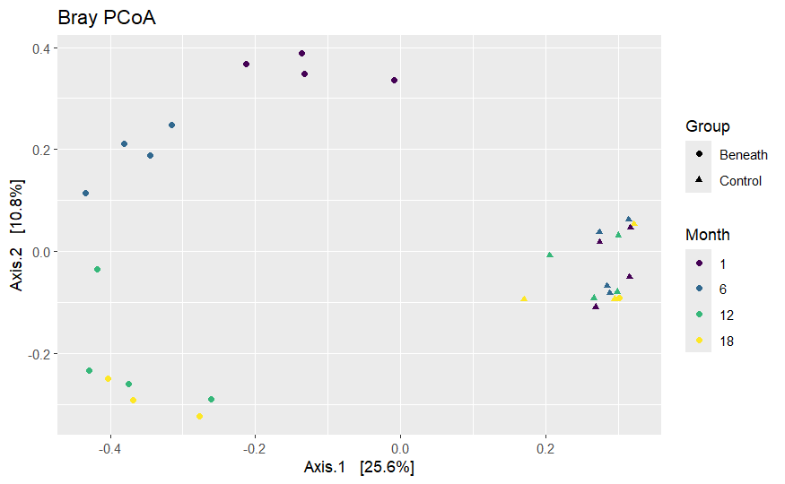

```r
PS_normal.prop <- transform_sample_counts(PS_normal, function(otu) otu/sum(otu))
ord.PCoA.bray <- ordinate(PS_normal.prop, method="PCoA", distance="bray")
plot_ordination(PS_normal.prop, ord.PCoA.bray, color="Month",shape = "Group", title="Bray PCoA")
```

## Hypothesis testing and ordination plots of beta diversity

PERMANOVA (Permutational Multivariate Analysis of Variance) was performed to indicate it there are statistical difference betwee the ‘beneath’ and control group at each sampling time point. PERMANOVA is a non-parametric statistical test used to compare groups of objects based on multivariate data. It is particularly useful in fields like ecology and biology for analyzing complex datasets where traditional parametric assumptions (like normality) may not hold. Betadisper (Multivariate Homogeneity of Group Dispersions) was also performed. It is a statistical method used to assess the homogeneity of variances (or dispersions) among groups in multivariate data. It is often used in conjunction with PERMANOVA to ensure that the assumption of homogeneity of dispersions is met. ### One Months

```r
#Set parameters
permu=9999#Amount of permutations
my.dist= "bray" # distances:"bray" "unifrac"  "wunifrac" "dpcoa" "chi.square"
adjstd.P="BH" # P value adjustment for pairwise comparison
```

```r
# Isolating the results of One month
PS_O_Bnth.Ctrl <- subset_samples(PS_normal, Month == "1")
# To ensure that the correct groups and values are being compared the samples an their ASVs were confirmed with the View() call
#View(PS_O_Bnth.Ctrl@sam_data)
#View(PS_O_Bnth.Ctrl@otu_table)
# Selecting the distance matrix
PS_O_Bnth.Ctrl_dist <- phyloseq::distance(PS_O_Bnth.Ctrl, method = my.dist)
metadata.PS_O_Bnth.Ctrl <- data.frame(sample_data(PS_O_Bnth.Ctrl))
#PERMANOVA analysis
adonis2(PS_O_Bnth.Ctrl_dist ~ Group, data = metadata.PS_O_Bnth.Ctrl,permutations = permu)
```

```
Permutation test for adonis under reduced model
Terms added sequentially (first to last)
Permutation: free
Number of permutations: 9999

adonis2(formula = PS_O_Bnth.Ctrl_dist ~ Group, data = metadata.PS_O_Bnth.Ctrl, permutations = permu)
         Df SumOfSqs      R2      F Pr(>F)
Group     1  0.96789 0.41402 4.2392 0.0292 *
Residual  6  1.36991 0.58598
Total     7  2.33780 1.00000
---
Signif. codes:  0 ‘***’ 0.001 ‘**’ 0.01 ‘*’ 0.05 ‘.’ 0.1 ‘ ’ 1
```

```r
# Dispersion around the Group centroid analysis
Dispersion.O_Bnth.Ctrl <- betadisper(PS_O_Bnth.Ctrl_dist,metadata.PS_O_Bnth.Ctrl$Group,type = "centroid")
# Homogeneity of the dispersion
permutest(Dispersion.O_Bnth.Ctrl, permutations = permu, pairwise = F)
```

```
Permutation test for homogeneity of multivariate dispersions
Permutation: free
Number of permutations: 9999

Response: Distances
          Df    Sum Sq    Mean Sq      F N.Perm Pr(>F)
Groups     1 0.0008031 0.00080314 1.2972   9999 0.3115
Residuals  6 0.0037148 0.00061913
```

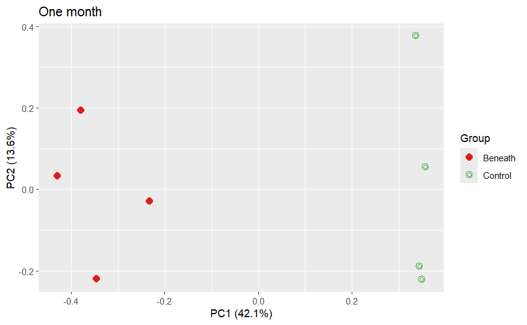

```r
# Plot
ord.PCoA.bray_One <- ordinate(PS_O_Bnth.Ctrl, method="PCoA", distance="bray")
  plot_ordination(PS_O_Bnth.Ctrl, ord.PCoA.bray_One,
                  type = "samples",
                  color="Group",
                  shape = "Group",
                  title="One month")+
  geom_point(size = 3)+
  scale_colour_manual(values = c("#E31A1C","#33A02C"))+
  scale_shape_manual(values = c(16,1))+
#  geom_richtext(data=tibble(x=c(0.0), y=c(-0.38))
#                ,aes(x=x, y=y, label= paste0("PERMANOVA: R<sup>2</sup> = 0.41 </sup> *p* = 0.0284")), size= 3, inherit.aes = F)+
  labs(x="PC1 (42.1%)",y="PC2 (13.6%)")
```

```r
dis_O <- data.frame(group=Dispersion.O_Bnth.Ctrl$group, distances=Dispersion.O_Bnth.Ctrl$distances)
Dispersion.O_Bnth.Ctr_box <- ggplot(dis_O, aes(x=group, y=distances, fill=group)) +
  scale_fill_manual(values = c("#E31A1C","#33A02C"))+
  geom_boxplot()+
  #  labs(title = "One month")+
  xlab("One month") +
  ylab("Distance to centroid") +
 theme(legend.position = "none")
```

## Six months

### Hypothesis tests

```r
PS_S_Bnth.Ctrl <- subset_samples(PS_normal, Month == "6")
#View(PS_S_Bnth.Ctrl@sam_data)
#View(PS_S_Bnth.Ctrl@otu_table)
PS_S_Bnth.Ctrl_dist <- phyloseq::distance(PS_S_Bnth.Ctrl, method = my.dist)
metadata.PS_S_Bnth.Ctrl <- data.frame(sample_data(PS_S_Bnth.Ctrl))
adonis2(PS_S_Bnth.Ctrl_dist ~ Group, data = metadata.PS_S_Bnth.Ctrl,permutations = permu)
```

```
Permutation test for adonis under reduced model
Terms added sequentially (first to last)
Permutation: free
Number of permutations: 9999

adonis2(formula = PS_S_Bnth.Ctrl_dist ~ Group, data = metadata.PS_S_Bnth.Ctrl, permutations = permu)
         Df SumOfSqs     R2      F Pr(>F)
Group     1   1.2308 0.4937 5.8507 0.0276 *
Residual  6   1.2622 0.5063
Total     7   2.4930 1.0000
---
Signif. codes:  0 ‘***’ 0.001 ‘**’ 0.01 ‘*’ 0.05 ‘.’ 0.1 ‘ ’ 1
```

```r
Dispersion.S_Bnth.Ctrl <- betadisper(PS_S_Bnth.Ctrl_dist,metadata.PS_S_Bnth.Ctrl$Group,type = "centroid")
permutest(Dispersion.S_Bnth.Ctrl, permutations = permu, pairwise = F)
```

```
Permutation test for homogeneity of multivariate dispersions
Permutation: free
Number of permutations: 9999

Response: Distances
          Df    Sum Sq   Mean Sq      F N.Perm Pr(>F)
Groups     1 0.0060811 0.0060811 19.438   9999  1e-04 ***
Residuals  6 0.0018771 0.0003128
---
Signif. codes:  0 ‘***’ 0.001 ‘**’ 0.01 ‘*’ 0.05 ‘.’ 0.1 ‘ ’ 1
```

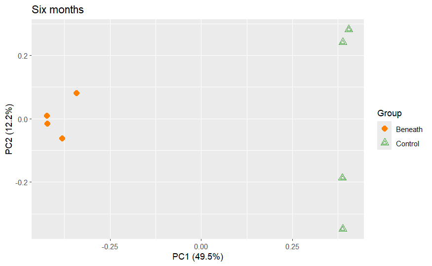

```r
## Plot
ord.PCoA.bray_Six <- ordinate(PS_S_Bnth.Ctrl, method="PCoA", distance="bray")
  plot_ordination(PS_S_Bnth.Ctrl, ord.PCoA.bray_Six,
                  type = "samples",
                  color="Group",
                  shape = "Group",
                  title="Six months")+
  geom_point(size = 3)+
  scale_colour_manual(values = c("#FF7F00", "#33A02C"))+
  scale_shape_manual(values = c(16,2))+
#  geom_richtext(data=tibble(x=c(0.0), y=c(-0.29))
#                ,aes(x=x, y=y, label= paste0("PERMANOVA: R<sup>2</sup> = 0.49 </sup> *p* = 0.026")), size= 3, inherit.aes = F)+
  labs(x="PC1 (49.5%)",y="PC2 (12.2%)")
```

```r
dis_S <- data.frame(group=Dispersion.S_Bnth.Ctrl$group, distances=Dispersion.S_Bnth.Ctrl$distances)
Dispersion.S_Bnth.Ctr_box <-  ggplot(dis_S, aes(x=group, y=distances, fill=group)) +
  scale_fill_manual(values = c("#FF7F00", "#33A02C"))+
  geom_boxplot()+
  #  labs(title = "One month")+
  xlab("Six months") +
  ylab("Distance to centroid") +
  theme(legend.position = "none")
```

# Twelve Months

## Hypothesis test

```r
PS_T_Bnth.Ctrl <- subset_samples(PS_normal, Month == "12")
#View(PS_T_Bnth.Ctrl@sam_data)
#View(PS_T_Bnth.Ctrl@otu_table)
PS_T_Bnth.Ctrl_dist <- phyloseq::distance(PS_T_Bnth.Ctrl, method = my.dist)
metadata.PS_T_Bnth.Ctrl <- data.frame(sample_data(PS_T_Bnth.Ctrl))
adonis2(PS_T_Bnth.Ctrl_dist ~ Group, data = metadata.PS_T_Bnth.Ctrl,permutations = permu)
```

```
Permutation test for adonis under reduced model
Terms added sequentially (first to last)
Permutation: free
Number of permutations: 9999

adonis2(formula = PS_T_Bnth.Ctrl_dist ~ Group, data = metadata.PS_T_Bnth.Ctrl, permutations = permu)
         Df SumOfSqs      R2      F Pr(>F)
Group     1   1.0253 0.38231 3.7136 0.0289 *
Residual  6   1.6565 0.61769
Total     7   2.6818 1.00000
---
Signif. codes:  0 ‘***’ 0.001 ‘**’ 0.01 ‘*’ 0.05 ‘.’ 0.1 ‘ ’ 1
```

```r
Dispersion.T_Bnth.Ctrl <- betadisper(PS_T_Bnth.Ctrl_dist,metadata.PS_T_Bnth.Ctrl$Group,type = "centroid")
permutest(Dispersion.T_Bnth.Ctrl, permutations = permu, pairwise = F)
```

```
Permutation test for homogeneity of multivariate dispersions
Permutation: free
Number of permutations: 9999

Response: Distances
          Df    Sum Sq   Mean Sq      F N.Perm Pr(>F)
Groups     1 0.0007544 0.0007544 0.4459   9999  0.537
Residuals  6 0.0101502 0.0016917
```

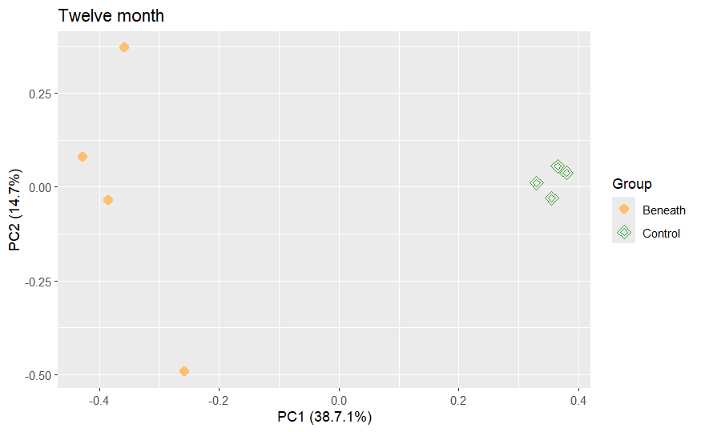

```r
#Plot
ord.PCoA.bray_Twelve <- ordinate(PS_T_Bnth.Ctrl, method="PCoA", distance="bray")
plot_ordination(PS_T_Bnth.Ctrl, ord.PCoA.bray_Twelve,
                  type = "samples",
                  color="Group",
                  shape = "Group",
                  title="Twelve month")+
  geom_point(size = 3)+
  scale_colour_manual(values = c("#FDBF6F", "#33A02C"))+
  scale_shape_manual(values = c(16,5))+
#  geom_richtext(data=tibble(x=c(0.0), y=c(-0.4))
#                ,aes(x=x, y=y, label= paste0("PERMANOVA: R<sup>2</sup> = 0.38 </sup> *p* = 0.028")), size= 3, inherit.aes = F)+
  labs(x="PC1 (38.7.1%)",y="PC2 (14.7%)")
```

```r
dis_T <- data.frame(group=Dispersion.T_Bnth.Ctrl$group, distances=Dispersion.T_Bnth.Ctrl$distances)
Dispersion.T_Bnth.Ctrl_box <- ggplot(dis_T, aes(x=group, y=distances, fill=group)) +
  scale_fill_manual(values = c("#FDBF6F", "#33A02C"))+
  geom_boxplot()+
  #  labs(title = "One month")+
  xlab("Twelve months") +
  ylab("Distance to centroid") +
theme(legend.position = "none")
```

# Eighteen months

```r
PS_E_Bnth.Ctrl <- subset_samples(PS_normal, Month == "18")
#View(PS_E_Bnth.Ctrl@sam_data)
#View(PS_E_Bnth.Ctrl@otu_table)
PS_E_Bnth.Ctrl_dist <- phyloseq::distance(PS_E_Bnth.Ctrl, method = my.dist)
metadata.PS_E_Bnth.Ctrl <- data.frame(sample_data(PS_E_Bnth.Ctrl))
adonis2(PS_E_Bnth.Ctrl_dist ~ Group, data = metadata.PS_E_Bnth.Ctrl,permutations = permu)
```

```
'nperm' >= set of all permutations: complete enumeration.
Set of permutations < 'minperm'. Generating entire set.
```

```
Permutation test for adonis under reduced model
Terms added sequentially (first to last)
Permutation: free
Number of permutations: 5039

adonis2(formula = PS_E_Bnth.Ctrl_dist ~ Group, data = metadata.PS_E_Bnth.Ctrl, permutations = permu)
         Df SumOfSqs      R2      F Pr(>F)
Group     1  0.56391 0.26207 1.7758 0.1429
Residual  5  1.58780 0.73793
Total     6  2.15171 1.00000
```

```r
Dispersion.E_Bnth.Ctrl <- betadisper(PS_E_Bnth.Ctrl_dist,metadata.PS_E_Bnth.Ctrl$Group,type = "centroid")
permutest(Dispersion.E_Bnth.Ctrl, permutations = permu, pairwise = F)
```

```
'nperm' >= set of all permutations: complete enumeration.
Set of permutations < 'minperm'. Generating entire set.
```

```
Permutation test for homogeneity of multivariate dispersions
Permutation: free
Number of permutations: 5039

Response: Distances
          Df   Sum Sq   Mean Sq      F N.Perm Pr(>F)
Groups     1 0.003327 0.0033270 0.4829   5039 0.5431
Residuals  5 0.034449 0.0068899
```

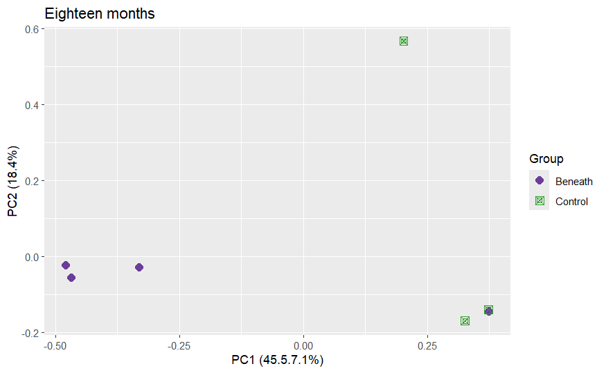

```r
# Plots
ord.PCoA.bray_Eighteen <- ordinate(PS_E_Bnth.Ctrl, method="PCoA", distance="bray")
  plot_ordination(PS_E_Bnth.Ctrl, ord.PCoA.bray_Eighteen,
                  type = "samples",
                  color="Group",
                  shape = "Group",
                  title="Eighteen months")+
  geom_point(size = 3)+
  scale_colour_manual(values = c("#6A3D9A", "#33A02C"))+
  scale_shape_manual(values = c(16,7))+
#  geom_richtext(data=tibble(x=c(-0.075), y=c(-0.15))
#                ,aes(x=x, y=y, label= paste0("PERMANOVA: R<sup>2</sup> = 0.26 </sup> *p* = 0.143")), size= 3, inherit.aes = F)+
  labs(x="PC1 (45.5.7.1%)",y="PC2 (18.4%)")
```

```r
dis_E <- data.frame(group=Dispersion.E_Bnth.Ctrl$group, distances=Dispersion.E_Bnth.Ctrl$distances)
Dispersion.E_Bnth.Ctrl_box <- ggplot(dis_E, aes(x=group, y=distances, fill=group)) +
  scale_fill_manual(values = c("#6A3D9A", "#33A02C"))+
  geom_boxplot()+
  #  labs(title = "One month")+
  xlab("Eighteen months") +
  ylab("Distance to centroid") +
  theme(legend.position = "none")
```

# LEfSe

LEfSe (Linear Discriminant Analysis Effect Size) is a statistical tool used for identifying features (such as organisms, genes, or functions) that are significantly different between two or more biological conditions or classes. It is particularly useful in metagenomic studies for discovering biomarkers that explain the differences between microbial communities.

```r
#Subset taxa
PSL <- subset_taxa(PS_normal, Kingdom=="Bacteria")
PSL <- subset_taxa(PSL, Kingdom!= "unassigned")
PSL <- subset_taxa(PSL, Phylum!= "unassigned")
PSL <- subset_taxa(PSL,`Class`!= "unassigned")
PSL <- subset_taxa(PSL,`Order`!= "unassigned")
PSL <- subset_taxa(PSL,`Family`!= "unassigned")
PSL <- subset_taxa(PSL,`Genus`!= "unassigned")

PSL_M1 <-  subset_samples(PSL, Month == "1")
PSL_M6 <-  subset_samples(PSL, Month == "6")
PSL_M12 <-  subset_samples(PSL, Month == "12")
PSL_M18 <-  subset_samples(PSL, Month == "18")
PSL
```

```
phyloseq-class experiment-level object
otu_table()   OTU Table:         [ 8173 taxa and 31 samples ]
sample_data() Sample Data:       [ 31 samples by 4 sample variables ]
tax_table()   Taxonomy Table:    [ 8173 taxa by 6 taxonomic ranks ]
refseq()      DNAStringSet:      [ 8173 reference sequences ]
```

```r
my_LEfSe_tranform <- "identity"
#my_LEfSe_cols <- c(Beneath = "#CC6666",Control = "#66CC99")
my_LEfSe_cols_B <- c(Beneath = "red",Control = "lightgreen")##E31A1C
#my_LEfSe_cols_B <- c(Beneath = "red")
```

## Month 1

```r
PSL_M1_p <-  prune_taxa(names(sort(taxa_sums(PSL_M1),TRUE)), PSL_M1) #[1:40], PSL_M1)
tax_table(PSL_M1_p) <- tax_table(PSL_M1_p)[,2:4]
PS_LEfSe_M1 <-
  run_lefse(PSL_M1_p,group = "Group",
            taxa_rank = "all",
            transform = my_LEfSe_tranform,
            norm = "none",
            kw_cutoff = 0.05,
            lda_cutoff = 2.65,#2.65
            bootstrap_n = 30,
            bootstrap_fraction = 2/3,
            wilcoxon_cutoff = 0.05,
            multigrp_strat = T,
            strict = c("0", "1", "2"),
            #  sample_min = 2,
            only_same_subgrp = F,
            curv = T
  )
# view(marker_table(PS_LEfSe_M1))
# markers_M1 <- marker_table(PS_LEfSe_M1)
# markers_M1 <- as.tibble(markers_M1)
# write.csv(markers_M1, file = "MMarkers_M1.csv")
```

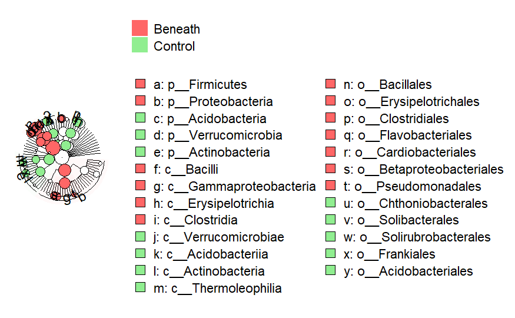

```r
LEfSe_Clad_M1 <-
  plot_cladogram(PS_LEfSe_M1,
                 color = c(Beneath = "#FF6666",Control = "lightgreen"),#"#F91C1C"
                 only_marker = F,
                 # branch_size = 1,
                 alpha = 0.04,
                 node_size_scale = 1.5,
                 node_size_offset = 0,
                 clade_label_level = 6,
                 clade_label_font_size = 5,
                 #annotation_shape = 22,
                 #annotation_shape_size = 4,
                 #group_legend_param = list(),
                 marker_legend_param = list())+
  #theme(legend.position = "bottom")+
  #theme(legend.position = "none")+
  theme(legend.text = element_text(size = 13)
  )+
  # ggtitle("One month")+
  theme(plot.title = element_text(size=22,hjust = 0.5))
LEfSe_Clad_M1
```

As many taxa were identified, some graphical parameters were exceeded, resulting in some warnings. The plot is clearer when save in the parameters below. # ggsave(file=“M1_LEfSe_Clado_LDA3.svg”, LEfSe_Clad_M1, # width = 400, height = 200, units = “mm”)

Genera that exceeded an LDA score of 2.65 in a bar plot

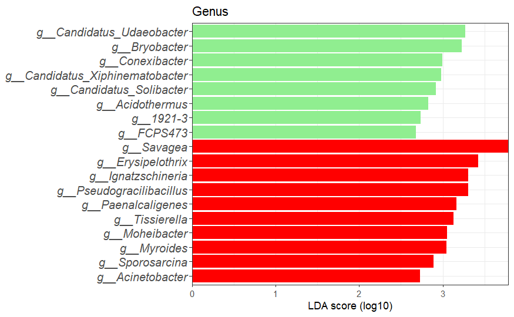

```r
PSL_M1_p <-  prune_taxa(names(sort(taxa_sums(PSL_M1),TRUE)), PSL_M1) #[1:40], PSL_M1)
tax_table(PSL_M1_p) <- tax_table(PSL_M1_p)[,6]
PS_LEfSe_M1 <-
  run_lefse(PSL_M1_p,group = "Group",
            taxa_rank = "all",
            transform = my_LEfSe_tranform,
            norm = "none",
            kw_cutoff = 0.05,
            lda_cutoff = 2.65,#2.
            bootstrap_n = 30,
            bootstrap_fraction = 2/3,
            wilcoxon_cutoff = 0.05,
            multigrp_strat = T,
            strict = c("0", "1", "2"),
            #  sample_min = 2,
            only_same_subgrp = F,
            curv = T
  )

ef_bar_plot_M1 <-
  plot_ef_bar(PS_LEfSe_M1,label_level = 1,
              max_label_len = 90, markers = NULL)+
scale_fill_manual(values = my_LEfSe_cols_B)+
  theme(axis.text.y=element_text(face="italic", size = 12))+#theme(axis.text.y=element_text(face="italic", size = 12))+
  theme(legend.position = "none")+
  theme(legend.text = element_text(size = 16)+
          theme(strip.background = element_blank())
  )+
  ggtitle("Genus")
ef_bar_plot_M1
```

and an abundance plot at the genus level.

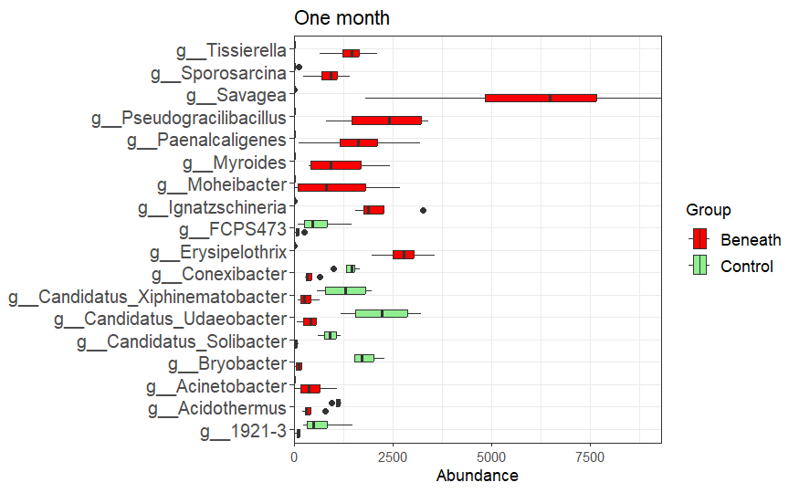

```r
plot_abundance(PS_LEfSe_M1, group = "Group")+
  scale_fill_manual(values = my_LEfSe_cols_B)+
  theme(axis.text.y=element_text( size = 12))+#theme(axis.text.y=element_text(face="italic", size = 12))+
  theme(legend.position = "right")+
  theme(legend.text = element_text(size = 16)+
          theme(strip.background = element_blank())
  )+
  ggtitle("One month")
```

# Month 6

[figure not shown]

```r
PSL_M6_p <-  prune_taxa(names(sort(taxa_sums(PSL_M6),TRUE)), PSL_M6)#)[1:40], PSL_M6)
tax_table(PSL_M6_p) <- tax_table(PSL_M6_p)[,2:4]
PS_LEfSe_M6 <-
  run_lefse(PSL_M6_p,group = "Group",
            taxa_rank = "all",
            transform = my_LEfSe_tranform,
            norm = "none",
            kw_cutoff = 0.05,
            lda_cutoff = 2.65,#2.65
            bootstrap_n = 30,
            bootstrap_fraction = 2/3,
            wilcoxon_cutoff = 0.05,
            multigrp_strat = F,
            strict = c("0", "1", "2"),
            #  sample_min = 2,
            only_same_subgrp = F,
            curv = T
  )
# marker_table(PS_LEfSe_M6)
LEfSe_Clad_M6 <-
  plot_cladogram(PS_LEfSe_M6,
                 color = c(Beneath = "#FF7F00",Control = "lightgreen"),
                 only_marker = T,
                 #branch_size = 0.5,
                 alpha = 0.1,
                 node_size_scale = 1.5,
                 node_size_offset = 0,
                 clade_label_level = 6,
                 clade_label_font_size = 5,
                 #annotation_shape = 22,
                 #annotation_shape_size = 4,
                 #group_legend_param = list(),
                 marker_legend_param = list())+
  #theme(legend.position = "none")+
  theme(legend.text = element_text(size = 12)
  )+
  # ggtitle("Six months")+
  theme(plot.title = element_text(size=22,hjust = 0.5))
LEfSe_Clad_M6
```

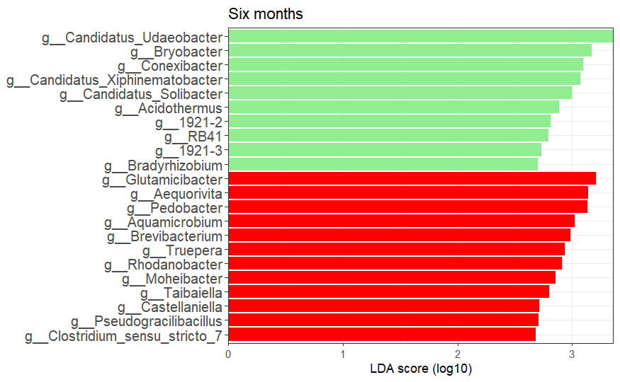

```r
PSL_M6_p <-  prune_taxa(names(sort(taxa_sums(PSL_M6),TRUE)), PSL_M6)#)[1:40], PSL_M6)
tax_table(PSL_M6_p) <- tax_table(PSL_M6_p)[,6]
PS_LEfSe_M6 <-
  run_lefse(PSL_M6_p,group = "Group",
            taxa_rank = "all",
            transform = my_LEfSe_tranform,
            norm = "none",
            kw_cutoff = 0.05,
            lda_cutoff = 2.65,#2.5
            bootstrap_n = 30,
            bootstrap_fraction = 2/3,
            wilcoxon_cutoff = 0.05,
            multigrp_strat = F,
            strict = c("0", "1", "2"),
            #  sample_min = 2,
            only_same_subgrp = F,
            curv = T
  )
# marker_table(PS_LEfSe_M6)
ef_bar_plot_M6 <-
  plot_ef_bar(PS_LEfSe_M6,label_level = 3, max_label_len = 90, markers = NULL)+
  scale_fill_manual(values = c(Beneath = "red",Control = "lightgreen"))+
  theme(axis.text.y=element_text(size = 12))+#theme(axis.text.y=element_text(face="italic", size = 12))
  theme(legend.position = "none")+
  theme(legend.text = element_text(size = 16)+
          theme(strip.background = element_blank())
  )+
  ggtitle("Six months")
ef_bar_plot_M6
```

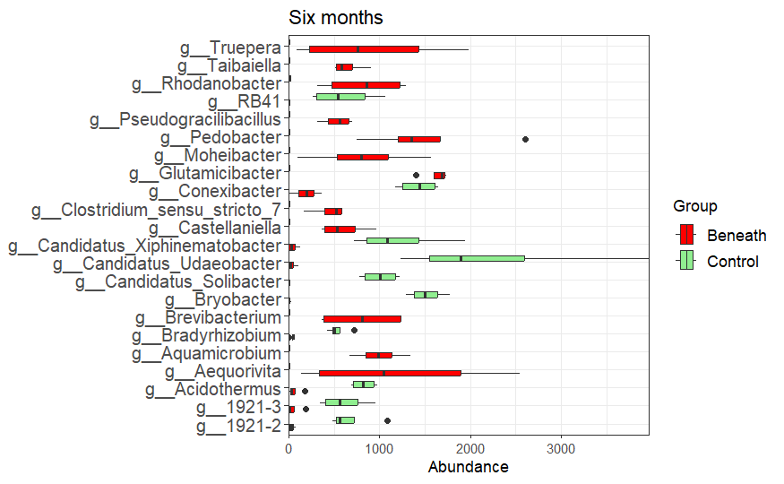

```r
plot_abundance(PS_LEfSe_M6, group = "Group")+
  scale_fill_manual(values = my_LEfSe_cols_B)+
  theme(axis.text.y=element_text( size = 12))+#theme(axis.text.y=element_text(face="italic", size = 12))+
  theme(legend.position = "right")+
  theme(legend.text = element_text(size = 16)+
          theme(strip.background = element_blank())
  )+
  ggtitle("Six months")
```

###Month 12####

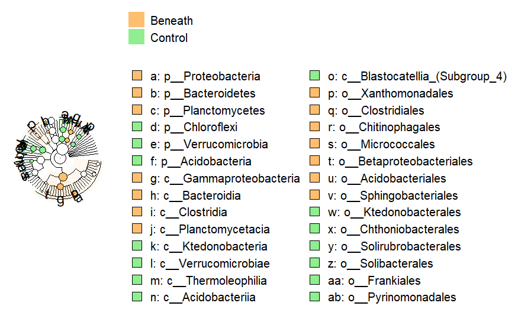

```r
PSL_M12_p <-  prune_taxa(names(sort(taxa_sums(PSL_M12),TRUE)), PSL_M12)#)[1:40], PSL_M12)
tax_table(PSL_M12_p) <- tax_table(PSL_M12_p)[,1:4]
PS_LEfSe_M12 <-
  run_lefse(PSL_M12_p,group = "Group",
            taxa_rank = "all",
            transform = my_LEfSe_tranform,
            norm = "none",
            kw_cutoff = 0.05,
            lda_cutoff = 2.5,#2.65
            bootstrap_n = 30,
            bootstrap_fraction = 2/3,
            wilcoxon_cutoff = 0.05,
            multigrp_strat = F,
            strict = c("0", "1", "2"),
            #  sample_min = 2,
            only_same_subgrp = F,
            curv = T
  )
# view(marker_table(PS_LEfSe_M12))

LEfSe_Clad_M12 <-
  plot_cladogram(PS_LEfSe_M12,
                 color = c(Beneath = "#FDBF6F",Control = "lightgreen"),
                 only_marker = F,
                 #branch_size = 0.5,
                 alpha = 0.1,
                 node_size_scale = 1.2,
                 node_size_offset = 0,
                 clade_label_level = 6,
                 clade_label_font_size = 5,
                 #annotation_shape = 22,
                 #annotation_shape_size = 4,
                 #group_legend_param = list(),
                 marker_legend_param = list())+
  #theme(legend.position = "none")+
  theme(legend.text = element_text(size = 12)
  )+
  # ggtitle("Twelve months")+
  theme(plot.title = element_text(size=22,hjust = 0.5))
LEfSe_Clad_M12
```

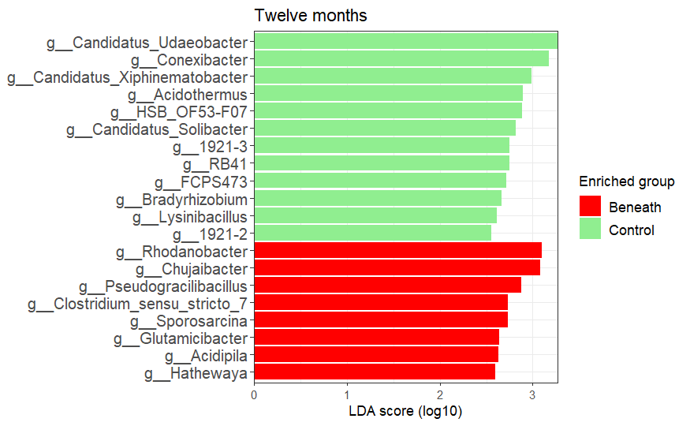

```r
PSL_M12_p <-  prune_taxa(names(sort(taxa_sums(PSL_M12),TRUE)), PSL_M12)#)[1:40], PSL_M12)
tax_table(PSL_M12_p) <- tax_table(PSL_M12_p)[,6]
PS_LEfSe_M12 <-
  run_lefse(PSL_M12_p,group = "Group",
            taxa_rank = "all",
            transform = my_LEfSe_tranform,
            norm = "none",
            kw_cutoff = 0.05,
            lda_cutoff = 2.5,#2.65
            bootstrap_n = 30,
            bootstrap_fraction = 2/3,
            wilcoxon_cutoff = 0.05,
            multigrp_strat = F,
            strict = c("0", "1", "2"),
            #  sample_min = 2,
            only_same_subgrp = F,
            curv = T
  )

ef_bar_plot_M12 <-
  plot_ef_bar(PS_LEfSe_M12,label_level = 3, max_label_len = 90, markers = NULL)+
  scale_fill_manual(values =c(Beneath = "red",Control = "lightgreen"))+
  theme(axis.text.y=element_text( size = 12))+#theme(axis.text.y=element_text(face="italic", size = 12))+
  theme(legend.position = "right")+
  theme(legend.text = element_text(size = 16)+
          theme(strip.background = element_blank())
  )+
  ggtitle("Twelve months")
ef_bar_plot_M12
```

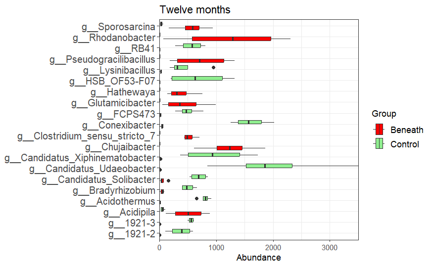

```r
plot_abundance(PS_LEfSe_M12, group = "Group")+
  scale_fill_manual(values = my_LEfSe_cols_B)+
  theme(axis.text.y=element_text( size = 12))+#theme(axis.text.y=element_text(face="italic", size = 12))+
  theme(legend.position = "right")+
  theme(legend.text = element_text(size = 16)+
          theme(strip.background = element_blank())
  )+
  ggtitle("Twelve months")
```

###Month 18####

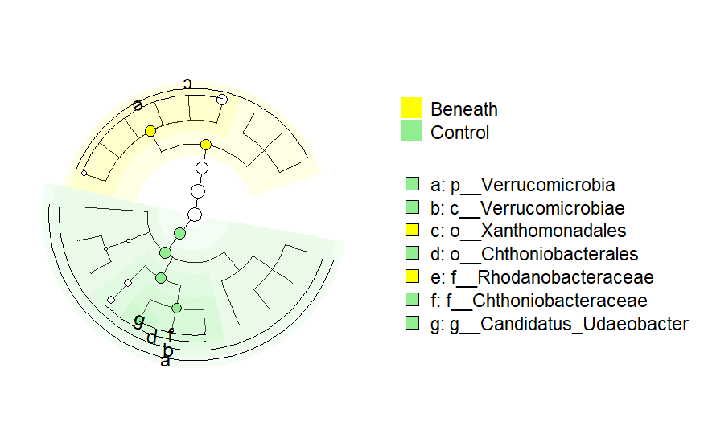

```r
PSL_M18_p <-  prune_taxa(names(sort(taxa_sums(PSL_M18),TRUE)), PSL_M18)#)[1:40], PSL_M18)
tax_table(PSL_M18_p) <- tax_table(PSL_M18_p)[,2:6]
PS_LEfSe_M18 <-
  run_lefse(PSL_M18_p,group = "Group",
            taxa_rank = "all",
            transform = my_LEfSe_tranform,
            norm = "none",
            kw_cutoff = 0.05,
            lda_cutoff = 2.65,#2.65
            bootstrap_n = 30,
            bootstrap_fraction = 2/3,
            wilcoxon_cutoff = 0.05,
            multigrp_strat = F,
            strict = c("0", "1", "2"),
            #  sample_min = 2,
            only_same_subgrp = F,
            curv = T
  )
#marker_table(PS_LEfSe_M18)

LEfSe_Clad_M18 <-
  plot_cladogram(PS_LEfSe_M18,
                 color = c(Beneath = "yellow",Control = "lightgreen"),
                 only_marker = T,
                 #branch_size = 0.5,
                 alpha = 0.1,
                 node_size_scale = 1,
                 node_size_offset = 0,
                 clade_label_level = 6,
                 clade_label_font_size = 5,
                 #annotation_shape = 22,
                 #annotation_shape_size = 4,
                 #group_legend_param = list(),
                 marker_legend_param = list())+
  #theme(legend.position = "none")+
  theme(legend.text = element_text(size = 14)
  )+
  # ggtitle("Eighteen months")+
  theme(plot.title = element_text(size=22,hjust = 0.5))
LEfSe_Clad_M18
```

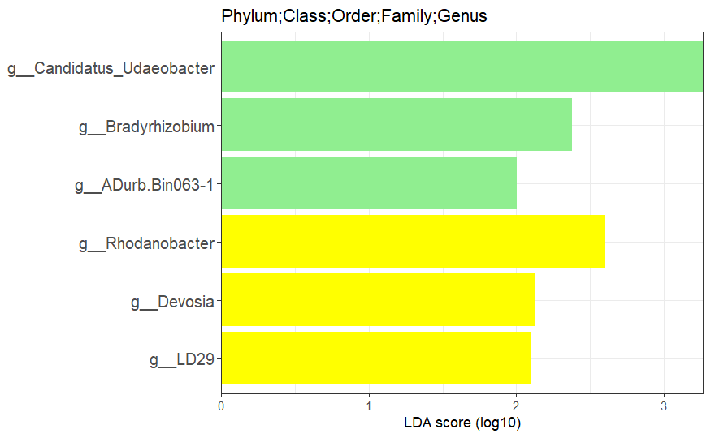

```r
PSL_M18_p <-  prune_taxa(names(sort(taxa_sums(PSL_M18),TRUE)), PSL_M18)#)[1:40], PSL_M18)
tax_table(PSL_M18_p) <- tax_table(PSL_M18_p)[,6]
PS_LEfSe_M18 <-
  run_lefse(PSL_M18_p,group = "Group",
            taxa_rank = "all",
            transform = my_LEfSe_tranform,
            norm = "none",
            kw_cutoff = 0.05,
            lda_cutoff = 2,#2.65
            bootstrap_n = 30,
            bootstrap_fraction = 2/3,
            wilcoxon_cutoff = 0.05,
            multigrp_strat = F,
            strict = c("0", "1", "2"),
            #  sample_min = 2,
            only_same_subgrp = F,
            curv = T
  )
ef_bar_plot_M18 <-
  plot_ef_bar(PS_LEfSe_M18,label_level = 3, max_label_len = 90, markers = NULL)+
  scale_fill_manual(values = c(Beneath = "yellow",Control = "lightgreen"))+
  theme(axis.text.y=element_text(size = 12))+#theme(axis.text.y=element_text(face="italic", size = 12))+
  theme(legend.position = "none")+
  theme(legend.text = element_text(size = 16)+
          theme(strip.background = element_blank())
  )+
  ggtitle("Phylum;Class;Order;Family;Genus")
ef_bar_plot_M18
```

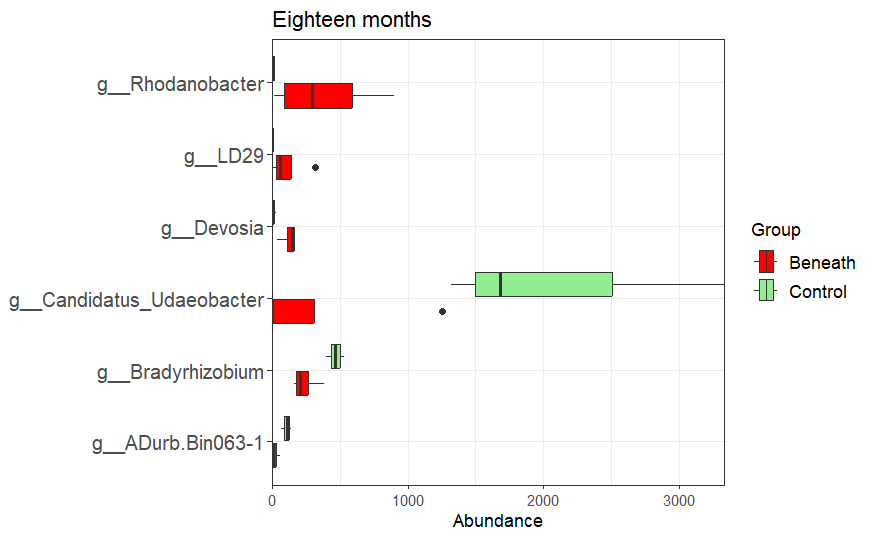

```r
plot_abundance(PS_LEfSe_M18, group = "Group")+
  scale_fill_manual(values = my_LEfSe_cols_B)+
  theme(axis.text.y=element_text( size = 12))+#theme(axis.text.y=element_text(face="italic", size = 12))+
  theme(legend.position = "right")+
  theme(legend.text = element_text(size = 16)+
          theme(strip.background = element_blank())
  )+
  ggtitle("Eighteen months")
```